# STAT656: Workshop on Multiple Linear Regression

# Loading objects and data

```r
packs = c('dplyr','ggplot2', 'caret','corrplot', 'e1071','readr')
lapply(packs,require,character.only=TRUE)
```

```
## [[1]]
## [1] TRUE
##
## [[2]]
## [1] TRUE
##
## [[3]]
## [1] TRUE
##
## [[4]]
## [1] TRUE
##
## [[5]]
## [1] TRUE
##
## [[6]]
## [1] TRUE
```

```r
dataSet = read_csv('linearRegressionWorkShop_data.csv')
Y       = select(dataSet,Y) %>% unlist()
X       = select(dataSet,-Y)
```

# Exploratory analysis

What are some things to check, and what is a reasonable order to check for them?

#### Answer

- data structures: what types of features do we have?
- missing values
- extreme observations
- skewness/transformations

## Data structures

```r
str(X)
```

```
## Classes 'spec_tbl_df', 'tbl_df', 'tbl' and 'data.frame': 1143 obs. of  38 variables:
##  $ x1 : chr  "low" "high" "low" "med" ...
##  $ x2 : chr  "low" "med" "high" "high" ...
##  $ x3 : num  0 0 0 0 0 0 0 0 0 1 ...
##  $ x4 : num  1 1 1 0 1 1 1 1 1 0 ...
##  $ x5 : num  0.1655 0.0446 0.0491 0.138 0.0514 ...
##  $ x6 : num  1.542 NA 0.623 1.35 1.526 ...
##  $ x7 : num  0.0864 0.0914 0.0677 0.1373 0.0423 ...
##  $ x8 : num  0.167 0.044 0.0492 0.1375 0.051 ...
##  $ x9 : num  9.14 10.46 8.01 10.37 9.62 ...
##  $ x10: num  9.89 11.67 9.09 9.14 11.53 ...
##  $ x11: num  10.25 10.03 8.98 9.57 9.04 ...
##  $ x12: num  8.62 10.23 9.93 8.99 9.04 ...
##  $ x13: num  9.38 11.44 10.72 8.41 8.12 ...
##  $ x14: num  9.36 11.05 9.2 9.26 10.32 ...
##  $ x15: num  9.49 9.64 11.81 11.04 10.38 ...
##  $ x16: num  11.22 9.73 8.55 9.73 10.4 ...
##  $ x17: num  10.57 7.49 10.09 10.38 9.84 ...
##  $ x18: num  8.53 10.89 10.77 9.22 8.1 ...
##  $ x19: num  11.49 9.4 9.52 9.6 10.62 ...
##  $ x20: num  8.71 11.38 10.88 10.07 8.49 ...
##  $ x21: num  8.89 11.34 9.32 9.95 9.26 ...
##  $ x22: num  10.14 9.66 8.91 10.64 10.46 ...
##  $ x23: num  9.47 11.01 10.53 10.83 10.07 ...
##  $ x24: num  9.51 9.16 10.13 11.1 9.56 ...
##  $ x25: num  9.85 11.18 10.94 10.71 9.8 ...
##  $ x26: num  9.72 9.84 9.5 8.98 11.49 ...
##  $ x27: num  10.09 10.68 9.82 9.35 10.21 ...
##  $ x28: num  9.63 10.8 9.48 9.79 8.92 ...
##  $ x29: num  9.8 9.04 10.32 11.49 9.44 ...
##  $ x30: num  8.96 8.98 7.89 9.59 11.21 ...
##  $ x31: num  9.58 10.93 9.47 9.85 9.92 ...
##  $ x32: num  10.95 9.11 11.6 10.51 8.29 ...
##  $ x33: num  9.71 8.95 11.9 9.85 10.51 ...
##  $ x34: num  10.49 9.9 9.42 10.04 10.62 ...
##  $ x35: num  10.7 10.7 10.5 10.9 10.6 ...
##  $ x36: num  10.65 10.46 10.47 10.74 9.47 ...
##  $ x37: num  9.09 10.36 9.44 11.69 11.22 ...
##  $ x38: num  10.79 10.98 NA 9.47 10.27 ...
##  - attr(*, "spec")=
```

[output cut: 26 more lines]

```
##   ..   x25 = col_double(),
##   ..   x26 = col_double(),
##   ..   x27 = col_double(),
##   ..   x28 = col_double(),
##   ..   x29 = col_double(),
##   ..   x30 = col_double(),
##   ..   x31 = col_double(),
##   ..   x32 = col_double(),
##   ..   x33 = col_double(),
##   ..   x34 = col_double(),
##   ..   x35 = col_double(),
##   ..   x36 = col_double(),
##   ..   x37 = col_double(),
##   ..   x38 = col_double()
##   .. )
```

```r
sapply(X,function(x){ length(unique(x)) })
```

```
##   x1   x2   x3   x4   x5   x6   x7   x8   x9  x10  x11  x12  x13  x14  x15
##    3    3    2    2 1143 1139 1143 1143 1143 1143 1143 1143 1143 1139 1143
##  x16  x17  x18  x19  x20  x21  x22  x23  x24  x25  x26  x27  x28  x29  x30
## 1143 1143 1139 1143 1139 1143 1143 1143 1143 1143 1143 1143 1143 1143 1143
##  x31  x32  x33  x34  x35  x36  x37  x38
## 1143 1139 1143 1143 1143 1143 1143  573
```

#### Answer

We have some qualitative features, some coded as character and some as numeric.

## Missing values

Let’s look for missing values

```r
anyNA(X)
```

```
## [1] TRUE
```

There are some indeed! Let’s visualize them with the following function:

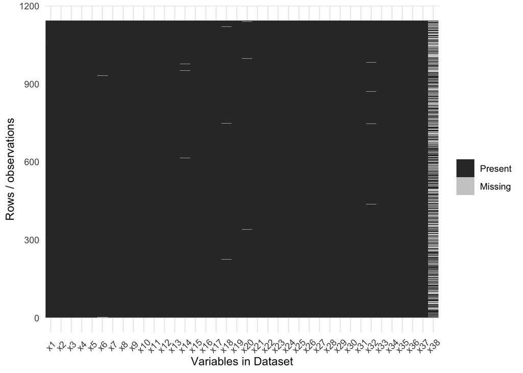

```r
ggplot_missing <- function(x){
    if(!require(reshape2)){warning('you need to install reshape2')}
    require(reshape2)
    require(ggplot2)
    #### This function produces a plot of the missing data pattern
    #### in x.  It is a modified version of a function in the 'neato' package

  x %>%
    is.na %>%
    melt %>%
    ggplot(data = .,
           aes(x = Var2,
               y = Var1)) +
    geom_raster(aes(fill = value)) +
    scale_fill_grey(name = "",
                    labels = c("Present","Missing")) +
    theme_minimal() +
    theme(axis.text.x  = element_text(angle=45, vjust=0.5)) +
    labs(x = "Variables in Dataset",
         y = "Rows / observations")
}
ggplot_missing(X)
```

There are some scattered missing values and then a lot of missing values in x38. We should remove x38 as it is likely to cause more harm than good to try to impute all those values.

```r
X = select(X,-x38)
```

Now, we can impute the remaining missing values. We can impute with ‘preProcess’

```r
require(RANN)
XimputeMedian = preProcess(X, method = 'medianImpute', k = 5)
Ximpute       = predict(XimputeMedian,X)
anyNA(Ximpute)
```

```
## [1] FALSE
```

## Back to data structures

We should convert the qualitative features to factors

```r
Xqual       = Ximpute %>% select(x1:x4) %>% mutate_all(factor)
Xquan       = Ximpute %>% select(-(x1:x4))
```

Now, these need to be converted to dummy variables for multiple linear regression

```r
dummyModel = dummyVars(~ ., data = Xqual, fullRank = TRUE)
XqualDummy = predict(dummyModel, Xqual)
```

## Extreme observations and Skewness

We should always be on the look out for extreme observations. Checking skewness and extreme observations are intertwined. We will check for skewness first

```r
skewed = apply(Xquan,2,skewness)
skewed
```

```
##            x5            x6            x7            x8            x9
##  1.942834e+00  2.509470e+00  1.891409e+00  1.943874e+00 -1.133332e+00
##           x10           x11           x12           x13           x14
## -9.897752e-01 -1.017200e+00 -1.220099e+00  1.075540e-01  1.267465e-01
##           x15           x16           x17           x18           x19
##  5.866571e-02  1.831447e-01  6.600411e-02 -4.577266e-02  6.994878e-02
##           x20           x21           x22           x23           x24
##  6.543639e-02 -1.810637e-02 -4.908409e-02 -5.305604e-02  6.488263e-02
##           x25           x26           x27           x28           x29
## -1.680018e-01 -2.354910e-02  7.708634e-02  1.023012e-05  7.215810e-02
##           x30           x31           x32           x33           x34
## -8.516362e-02 -1.620931e-02  1.632086e-02  1.569538e-01 -1.001451e-02
##           x35           x36           x37
## -2.058554e-02  1.837163e-02 -7.806919e-02
```

It looks like there are a few heavily skewed features.

```r
XquanYeoJ = Xquan %>%
  select_if(abs(skewed) > 1.5) %>%
  preProcess(method  = 'YeoJohnson') %>%
  predict(newdata    = Xquan)
```

Let’s plot one of these skewed features before and after transformation

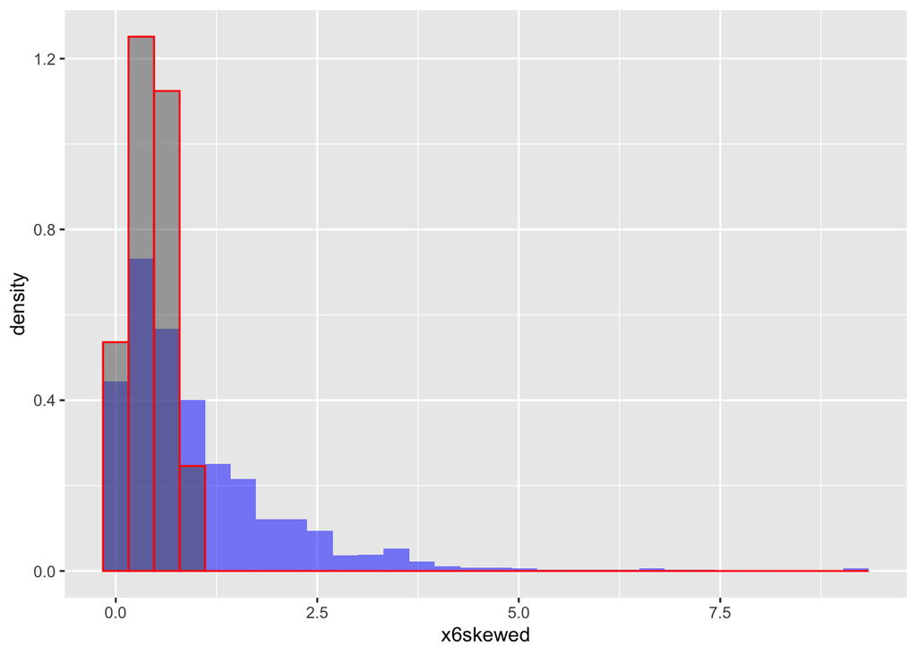

```r
plotData = data.frame('x6skewed' = Xquan$x6, 'x6unskewed' = XquanYeoJ$x6)
plotData %>% ggplot() +
  geom_histogram(aes(x=x6skewed, y = ..density..), alpha = 0.5,  fill = 'blue') +
  geom_histogram(aes(x = x6unskewed,  y = ..density..), alpha = 0.5, color = 'red')
```

Let’s check for extreme observations via PCA

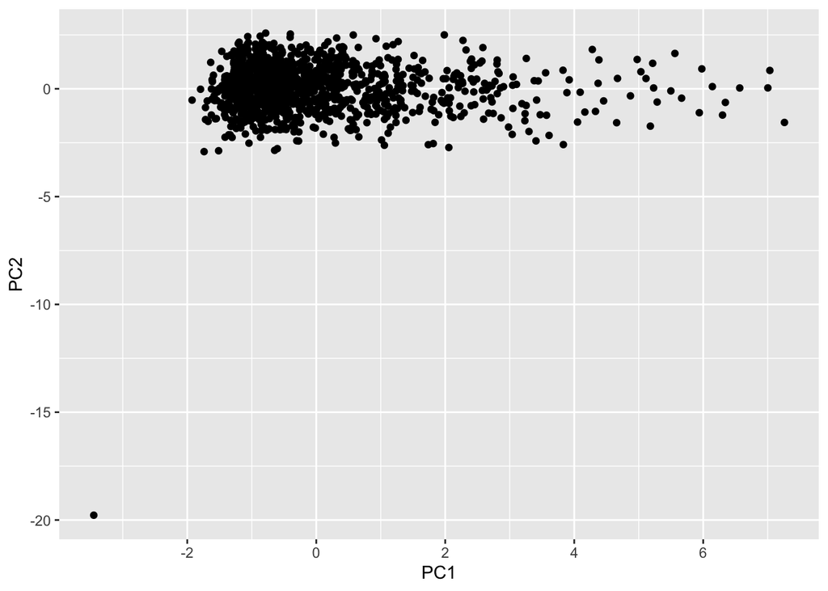

```r
pcaOut          = prcomp(XquanYeoJ,scale=TRUE,center=TRUE)
XquanYeoJscores = data.frame(pcaOut$x)
ggplot(data = XquanYeoJscores) +
  geom_point(aes(x = PC1, y = PC2))
```

Woah! We have an extreme observation for sure. Let’s take a look:

```r
extremeObs = which.min(XquanYeoJscores$PC1)
X[extremeObs,]
```

```
## # A tibble: 1 x 37
##   x1    x2       x3    x4      x5    x6    x7      x8    x9   x10   x11
##   <chr> <chr> <dbl> <dbl>   <dbl> <dbl> <dbl>   <dbl> <dbl> <dbl> <dbl>
## 1 med   med       0     1 0.00477 0.759 0.132 0.00626    -1    -1    -1
## # … with 26 more variables: x12 <dbl>, x13 <dbl>, x14 <dbl>, x15 <dbl>,
## #   x16 <dbl>, x17 <dbl>, x18 <dbl>, x19 <dbl>, x20 <dbl>, x21 <dbl>,
## #   x22 <dbl>, x23 <dbl>, x24 <dbl>, x25 <dbl>, x26 <dbl>, x27 <dbl>,
## #   x28 <dbl>, x29 <dbl>, x30 <dbl>, x31 <dbl>, x32 <dbl>, x33 <dbl>,
## #   x34 <dbl>, x35 <dbl>, x36 <dbl>, x37 <dbl>
```

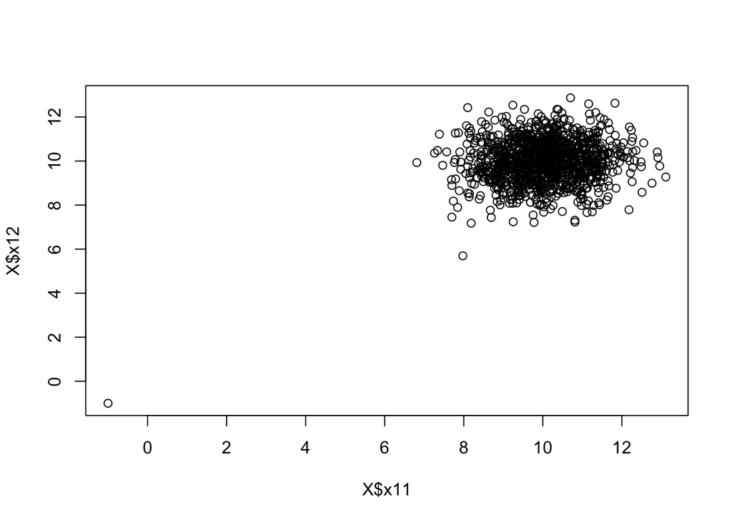

```r
plot(X$x11, X$x12)
```

It looks like an issue with the databasing, we will go ahead and remove that observation. We can either attempt to impute the values (by setting the infeasible values to NA) or remove the observation. Let’s remove the observation

(here, I’m just going to remove it now so as to not overly complicate the Rmd file. But it would be a good idea to go back and remove the observation from the beginning. )

```r
Xfull = cbind(XquanYeoJ,XqualDummy)[-30,]
Yno30 = Y[-30]

if(nrow(Xfull) != length(Yno30)){ warning('Something bad happened with removing that observation')}
```

# Correlation filtering

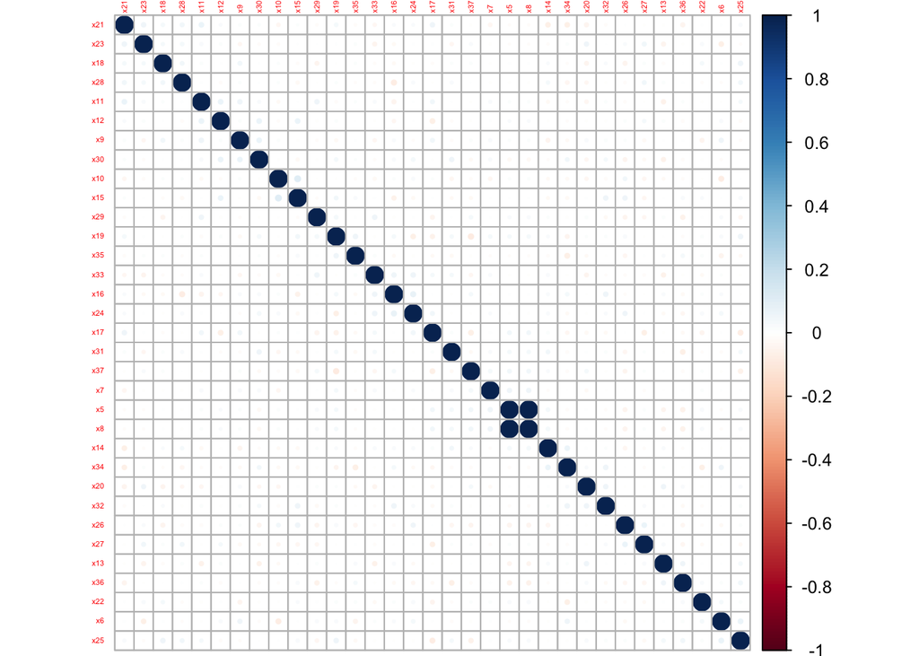

```r
corrplot(cor(Xfull %>% select(-contains('.'))), order = "hclust", tl.cex = .35)
```

It looks like there are two features that a quite correlated. We can use the correlation filtering

```r
highCorr = Xfull %>%
  select(-contains('.')) %>%
  cor %>%
  findCorrelation(.8, names = TRUE)

XfullCorrFilter = select(Xfull,-highCorr)
```

Now, let’s compute the apparent error, CV error, and test error. To compute the test error, let’s make a training/test split

```r
set.seed(1)
trainIndex = createDataPartition(Yno30, p = .75, list = FALSE) %>% as.vector(.)


Xtrain = XfullCorrFilter[trainIndex,]
Ytrain = Yno30[trainIndex]

Xtest = XfullCorrFilter[-trainIndex,]
Ytest = Yno30[-trainIndex]
```

#### Fit the multiple,linear regression

```r
trControl = trainControl(method = 'cv', number = 10)
lmOut     = train(x = Xtrain, y = Ytrain, method = "lm",
                  trControl = trControl)
```

#### Training error:

```r
Yhat = predict(lmOut, newdata = Xtrain)
mean(Yhat - Ytrain) ##oops, what happened?  What result did we get?
```

```
## [1] 1.303324e-13
```

```r
mean( (Yhat - Ytrain)**2 )
```

```
## [1] 1.163055
```

#### Test error

```r
YhatTest = predict(lmOut, newdata = Xtest)
mean( (YhatTest - Ytest)**2 )
```

```
## [1] 1.278982
```

#### CV estimate of test error

```r
mean(lmOut$resample$RMSE**2)
```

```
## [1] 1.28473
```

Let’s get a residual plot:

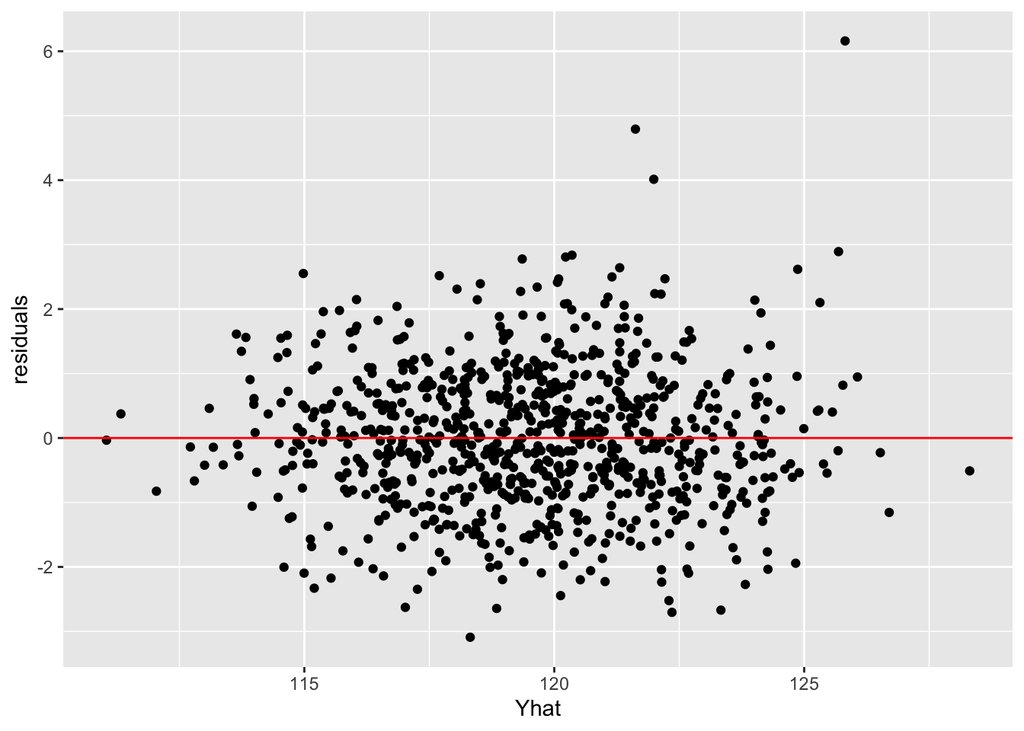

```r
residuals        = Ytrain - Yhat
residualPlotData = data.frame(residuals, Yhat)
ggplot(data = residualPlotData) +
    geom_point(aes(x = Yhat, y = residuals)) +
    geom_hline(yintercept = 0, color = 'red')
```

Those are good looking residuals. We can also compute the R^2

```r
SSE = sum( (Yhat - Ytrain)**2 )
TSS = sum( (mean(Ytrain) - Ytrain)**2 )
1 - SSE/TSS
```

```
## [1] 0.8647344
```